# Session 3

## Import the fpp library

library(fpp)

library(TSA)

## Box-Cox Exmaple:

Monthly anti-diabetic drug sales in Australia from 1992 to 2008 Time-series

Description Total monthly scripts for pharmaceutical products falling under ATC code A10, as recorded by the Australian Health Insurance Commission.

See ?a10 for additional information

### Plot the Time-series

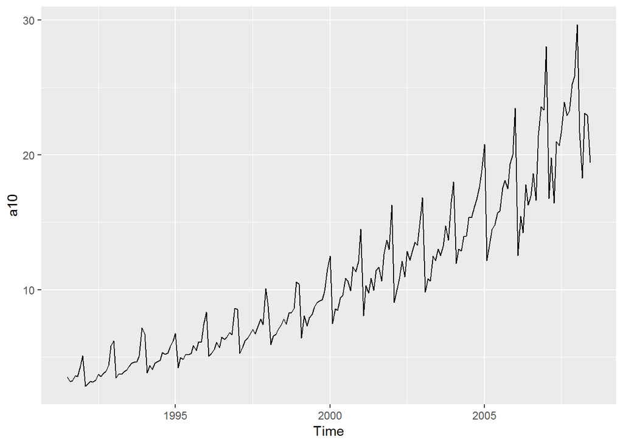

```r
autoplot(a10)
```

### Try four values of lambda in Box-Cox transformations

#### Box Cox Transformation

Description BoxCox() returns a transformation of the input variable using a Box-Cox transformation.

InvBoxCox() reverses the transformation.

Usage BoxCox(x, lambda) InvBoxCox(x, lambda, biasadj = FALSE, fvar = NULL)

See ?BoxCox for additional information

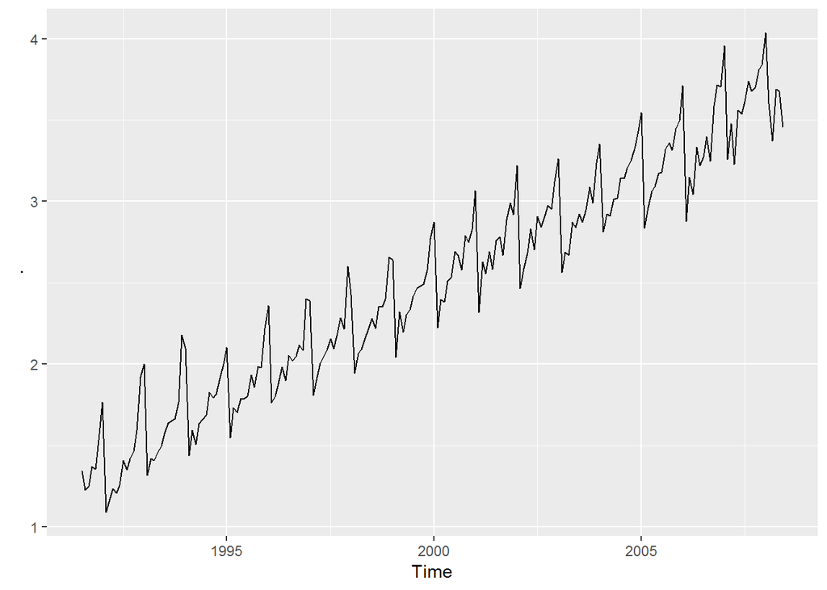

```r
a10 %>% BoxCox(lambda = .1) %>% autoplot()
```

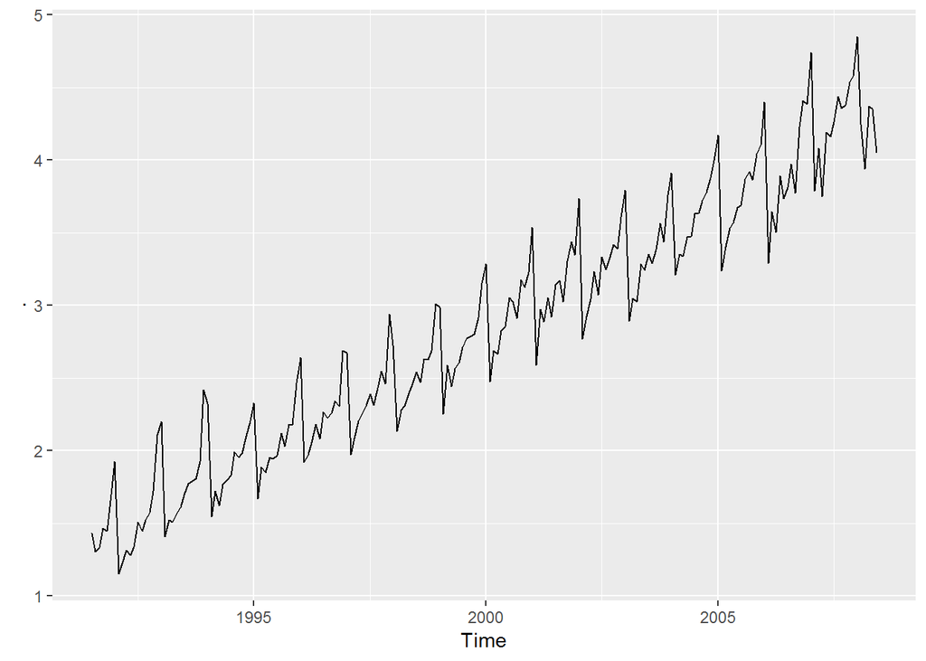

```r
a10 %>% BoxCox(lambda = 0.2) %>% autoplot()
```

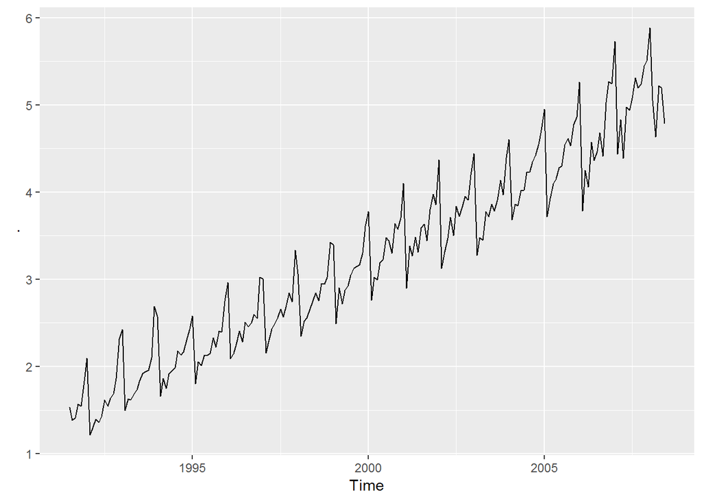

```r
a10 %>% BoxCox(lambda = 0.3) %>% autoplot()
```

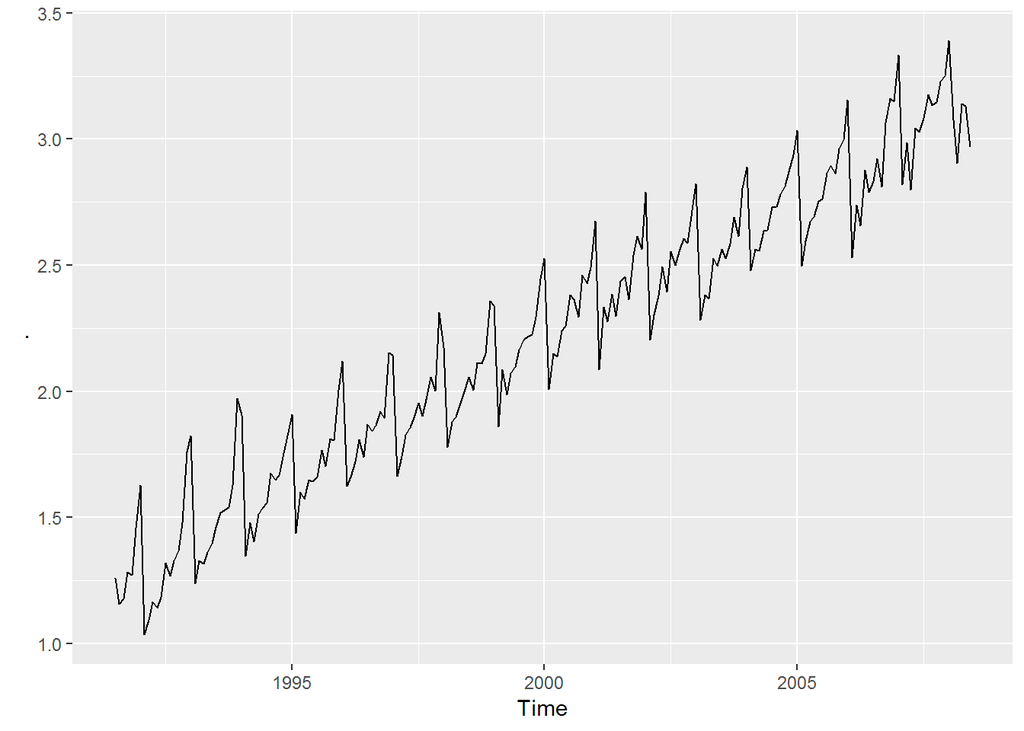

```r
a10 %>% BoxCox(lambda = 0) %>% autoplot() # natural log transformation
```

### Compare with BoxCox.lambda()

Automatic selection of Box Cox transformation parameter

Description If method==“guerrero”, Guerrero’s (1993) method is used, where lambda minimizes the coefficient of variation for subseries of x.

See ?BoxCox.lambda for additional information

```r
BoxCox.lambda(a10)
```

```
## [1] 0.1313326
```

## arima.sim() Example:

Simulate an ARIMA Model

See ?arima.sim for additional information

### Pure AR(2)

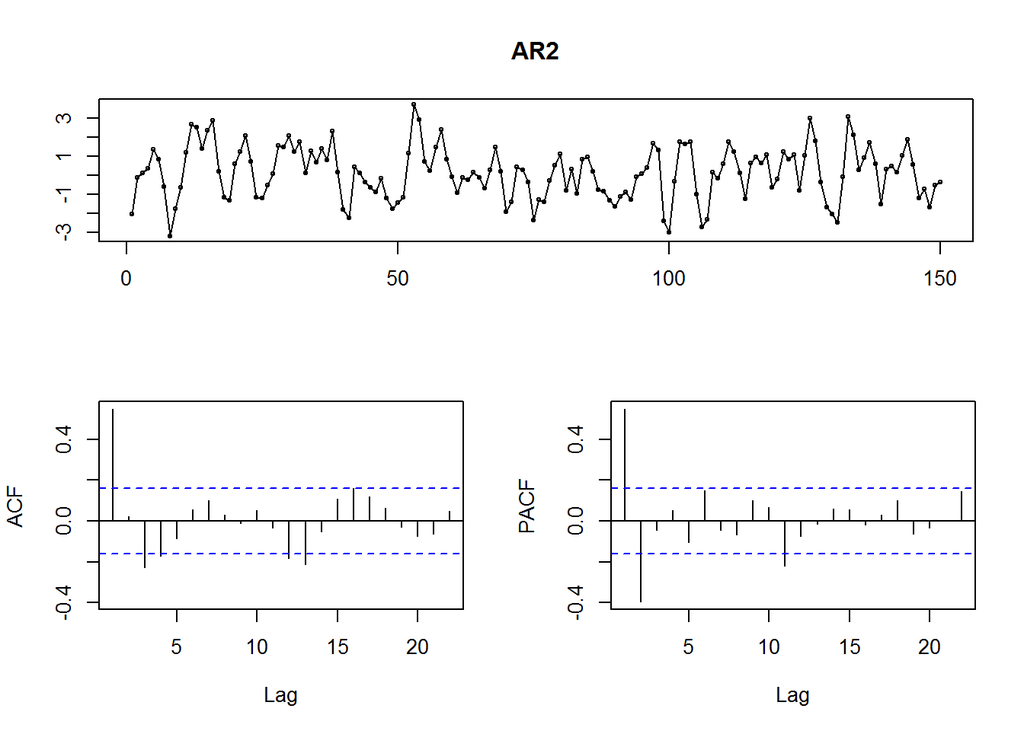

```r
win.graph(width=12, height=6,pointsize=12)
AR2 <- arima.sim(n = 150, list(order=c(2,0,0), ar=c(0.8, -0.4) ))
tsdisplay(AR2)
```

### Pure MA(1)

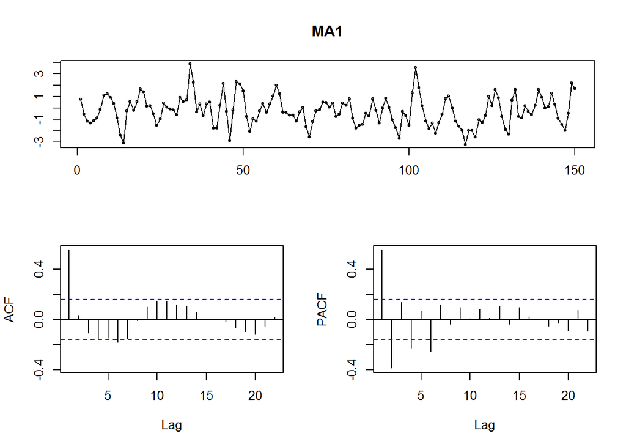

```r
win.graph(width=12, height=6,pointsize=12)
MA1 <- arima.sim(n = 150, list(order=c(0,0,1), ma=c(0.9) ))
tsdisplay(MA1)
```

### ARMA(2,1)

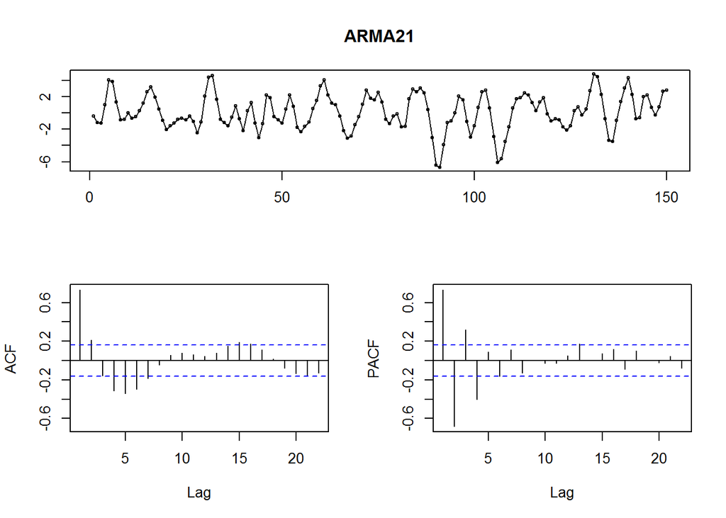

```r
win.graph(width=12, height=6,pointsize=12)
ARMA21 <- arima.sim(n = 150, list(order=c(2,0,1), ar =c(0.8, -0.4) ,ma=c(0.8897) ))
tsdisplay(ARMA21)
```

### AR + Mean to AR

```r
win.graph(width=12, height=6,pointsize=12)
AR2mean <- arima.sim(n = 150, list(order=c(2,0,0), ar =c(0.8, -0.4) )) + 10
mean(AR2mean) # ~=10
```

```
## [1] 9.946955
```

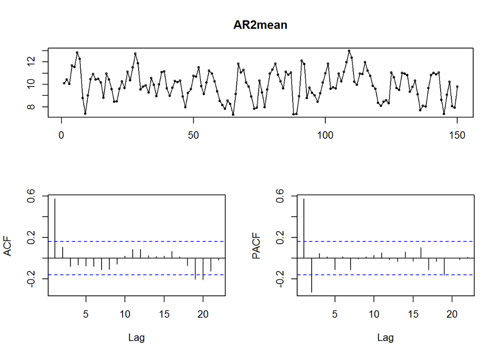

```r
tsdisplay(AR2mean)
```